# Seabirds Plastics Proteomics Bioinformatic Pipeline

# Adjusted Enrichment analysis

As we are working with a non-model organism (seabird) with proteomic data with unknown expected frequencies of the detect proteins, an adjusted enrichment analysis was designed. First we will map the detected proteins of the low plastic exposure group, this will act as a baseline for comparison. Next, the code will map the pathways of the proteins which were significantly different between the high and low plastic groups.

For this enrichment analysis we utilised the following 6 databases: GO_Molecular_Function_2023, GO_Cellular_Component_2023, GO_Biological_Process_2023, KEGG_2021_Human, WikiPathway_2021_Human, TRRUST_Transcription_Factors_2019

#### Control group enrichment analysis

Creating a list of genes detected in 70% of the control birds

```r
bird_column<-5:35 # Isolate the columns containing just protein counts

# Create a new data frame containing the Low plastic samples which represent our control for the enrichment analysis. This is created from df_trimmed minus the High Plastic samples.
Control_bird_df<-df_trimmed[,-bird_column[group_trimmed=="High Plastic"]]
```

Enrichment analysis (mapping) of the control birds

```r
# Extract the gene symbols from the control bird dataframe
genes_of_interest<-Control_bird_df$gene_symbol

# Create a list of all the databases available in Enrichr
databases<-listEnrichrDbs()

# Create a subset of the databases of interest
databases_of_interest<-c(
  "GO_Molecular_Function_2023",
  "GO_Cellular_Component_2023",
  "GO_Biological_Process_2023",
  "KEGG_2021_Human",
  "WikiPathway_2021_Human",
  "TRRUST_Transcription_Factors_2019")

# Perform enrichment using enrichr on the control genes
enrichment_control<-enrichr(as.character(genes_of_interest), databases = databases_of_interest)
```

#### Enrichment analysis (mapping) for the Significant Genes

Note this code is just grouping our genes into different biological pathways/locations/transcription factors. This enrichment analysis is not valid as it assumes we can detect all 22,000 genes

```r
# Subset the gene symbols of the significant genes (where the p_adjust is less than 0.05) from the trimmed dataframe.
genes_of_significance<-df_trimmed$gene_symbol[df_trimmed$p_adjust<0.05]

# Create a list of all the databases available in Enrichr
databases<-listEnrichrDbs()

# Create a subset of the databases of interest
databases_of_interest<-c("GO_Molecular_Function_2023",
                         "GO_Cellular_Component_2023",
                         "GO_Biological_Process_2023",
                         "KEGG_2021_Human",
                         "WikiPathway_2021_Human",
                         "TRRUST_Transcription_Factors_2019")

#Selecting our genes and uploading them to 6 different enrichment databases
enrichment_Sig<-enrichr(as.character(genes_of_significance), databases = databases_of_interest)
```

```
## Uploading data to Enrichr... Done.
##   Querying GO_Molecular_Function_2023... Done.
##   Querying GO_Cellular_Component_2023... Done.
##   Querying GO_Biological_Process_2023... Done.
##   Querying KEGG_2021_Human... Done.
##   Querying WikiPathway_2021_Human... Done.
##   Querying TRRUST_Transcription_Factors_2019... Done.
## Parsing results... Done.
```

Below is the enrichment analysis for the GO_Molecular_function database. The output observed in the View() function is where the data for Table 2 was obtained for each database.

The enrichment analysis is annotated in Chunk 12 and is repeated for each of the 6 databases.

1.GO_Molecular_function_2023 database

```r
# Building the significant and control protein data frames for the GO_Molecular_Function database
go_mol_function_Sig<-enrichment_Sig$GO_Molecular_Function_2023[,c("Term","Overlap","Genes")]
go_mol_function_Control<-enrichment_control$GO_Molecular_Function_2023[,c("Term","Overlap","Genes")]

# Building empty columns for the loop
go_mol_function_Sig$PermutationTest<-999
go_mol_function_Sig$ProteinNumber<-999
go_mol_function_Sig$ProteinNumberControl<-999
go_mol_function_Sig$TotalControlProtein<-nrow(Control_bird_df)
go_mol_function_Sig$TotalSignificant<-sum(df_trimmed$p_adjust<0.05)

# Loop through each row of the significant data frame
for(i in 1:nrow(go_mol_function_Sig)) {


  go_mol_function_Sig$ProteinNumber[i]<-as.numeric(sub("\\/.*", "", go_mol_function_Sig$Overlap[i])) # Extract and process data from the "Overlap" column

  if(go_mol_function_Sig$Term[i] %in% go_mol_function_Control$Term){
  Control_data<-go_mol_function_Control[go_mol_function_Control$Term==go_mol_function_Sig$Term[i],] # Check if the term is present in the control data frame

  go_mol_function_Sig$ProteinNumberControl[i]<-as.numeric(sub("\\/.*", "", Control_data$Overlap)) # Extract relevant information from the control data frame

  } else {
    go_mol_function_Sig$ProteinNumberControl[i]<-0 # If the term is not present in the control data, set ProteinNumberControl to 0
  }
}

# Trimming out the very low count pathways. There's no point saying a pathway is enriched with 2 genes
go_mol_function_Sig<- go_mol_function_Sig[go_mol_function_Sig$ProteinNumber>2,]

# Generate p-values by performing a permutation test
for(i in 1:nrow(go_mol_function_Sig)){

  control<-c(rep(1,go_mol_function_Sig$ProteinNumberControl[i]), rep(0,go_mol_function_Sig$TotalControlProtein[i] -
                                                                       go_mol_function_Sig$ProteinNumberControl[i])) # Create a control vector for permutation test

  repeats<-10000 # Perform a permutation test with 10,000 repeats

  n<-rep(9999, repeats)
  sum(control)

for (j in 1:repeats){

  n[j]<-sum(sample(control, go_mol_function_Sig$TotalSignificant[i]))

}

  significant<-go_mol_function_Sig$ProteinNumber[i] # Calculate the p.value based on the permutation test

  go_mol_function_Sig$PermutationTest[i]<- sum(n>=(significant))/repeats

  dat <- data.frame(
    "Control" = c(go_mol_function_Sig$ProteinNumberControl[i], (go_mol_function_Sig$TotalControlProtein[i] -
                                                                go_mol_function_Sig$ProteinNumberControl[i])),
    "Significant" = c(significant, (go_mol_function_Sig$TotalSignificant[i]-significant)),
    row.names = c("Pathway", "Non-pathway"),
    stringsAsFactors = FALSE
) # Create a data frame for pathway and non-pathway counts
  colnames(dat) <- c("Control", "Significant")

}

# GO_Molecular_Funciton Enrichment results
View(go_mol_function_Sig)
```

2. GO_Cellular_Component_2023 database

```r
GO_Cellular_Component_Sig<-enrichment_Sig$GO_Cellular_Component_2023[,c("Term","Overlap","Genes")]
GO_Cellular_Component_Control<-enrichment_control$GO_Cellular_Component_2023[,c("Term","Overlap","Genes")]

GO_Cellular_Component_Sig$PermutationTest<-999
GO_Cellular_Component_Sig$ProteinNumber<-999
GO_Cellular_Component_Sig$ProteinNumberControl<-999
GO_Cellular_Component_Sig$TotalControlProtein<-nrow(Control_bird_df)
GO_Cellular_Component_Sig$TotalSignificant<-sum(df_trimmed$p_adjust<0.05)

for(i in 1:nrow(GO_Cellular_Component_Sig)) {

  GO_Cellular_Component_Sig$ProteinNumber[i]<-as.numeric(sub("\\/.*", "", GO_Cellular_Component_Sig$Overlap[i]))

  if(GO_Cellular_Component_Sig$Term[i] %in% GO_Cellular_Component_Control$Term){
  Control_data<-GO_Cellular_Component_Control[GO_Cellular_Component_Control$Term==GO_Cellular_Component_Sig$Term[i],]

  GO_Cellular_Component_Sig$ProteinNumberControl[i]<-as.numeric(sub("\\/.*", "", Control_data$Overlap))

  } else {
    GO_Cellular_Component_Sig$ProteinNumberControl[i]<-0
  }
}

GO_Cellular_Component_Sig<- GO_Cellular_Component_Sig[GO_Cellular_Component_Sig$ProteinNumber>2,]

for(i in 1:nrow(GO_Cellular_Component_Sig)){

  control<-c(rep(1,GO_Cellular_Component_Sig$ProteinNumberControl[i]), rep(0,GO_Cellular_Component_Sig$TotalControlProtein[i] -
                                                                             GO_Cellular_Component_Sig$ProteinNumberControl[i]))

  repeats<-10000

  n<-rep(9999, repeats)
  sum(control)

for (j in 1:repeats){

  n[j]<-sum(sample(control, GO_Cellular_Component_Sig$TotalSignificant[i]))

}

  significant<-GO_Cellular_Component_Sig$ProteinNumber[i]

  GO_Cellular_Component_Sig$PermutationTest[i]<- sum(n>=(significant))/repeats

  dat <- data.frame(
    "Control" = c(GO_Cellular_Component_Sig$ProteinNumberControl[i], (GO_Cellular_Component_Sig$TotalControlProtein[i] -
                                                                      GO_Cellular_Component_Sig$ProteinNumberControl[i])),
    "Significant" = c(significant, (GO_Cellular_Component_Sig$TotalSignificant[i]-significant)),
    row.names = c("Pathway", "Non-pathway"), stringsAsFactors = FALSE
)
  colnames(dat) <- c("Control", "Significant")

  dat
}

View(GO_Cellular_Component_Sig)
```

3. GO_Biological_Process_2023 database

```r
GO_Bioloigcal_Process_Sig<-enrichment_Sig$GO_Biological_Process_2023[,c("Term","Overlap","Genes")]
GO_Bioloigcal_Process_Control<-enrichment_control$GO_Biological_Process_2023[,c("Term","Overlap","Genes")]

GO_Bioloigcal_Process_Sig$PermutationTest<-999
GO_Bioloigcal_Process_Sig$ProteinNumber<-999
GO_Bioloigcal_Process_Sig$ProteinNumberControl<-999
GO_Bioloigcal_Process_Sig$TotalControlProtein<-nrow(Control_bird_df)
GO_Bioloigcal_Process_Sig$TotalSignificant<-sum(df_trimmed$p_adjust<0.05)

for(i in 1:nrow(GO_Bioloigcal_Process_Sig)) {

  GO_Bioloigcal_Process_Sig$ProteinNumber[i]<-as.numeric(sub("\\/.*", "", GO_Bioloigcal_Process_Sig$Overlap[i]))

  if(GO_Bioloigcal_Process_Sig$Term[i] %in% GO_Bioloigcal_Process_Control$Term){
  Control_data<-GO_Bioloigcal_Process_Control[GO_Bioloigcal_Process_Control$Term==GO_Bioloigcal_Process_Sig$Term[i],]

  GO_Bioloigcal_Process_Sig$ProteinNumberControl[i]<-as.numeric(sub("\\/.*", "", Control_data$Overlap))

  } else {
    GO_Bioloigcal_Process_Sig$ProteinNumberControl[i]<-0
  }
}

GO_Bioloigcal_Process_Sig<- GO_Bioloigcal_Process_Sig[GO_Bioloigcal_Process_Sig$ProteinNumber>2,]

for(i in 1:nrow(GO_Bioloigcal_Process_Sig)){

  control<-c(rep(1,GO_Bioloigcal_Process_Sig$ProteinNumberControl[i]), rep(0,GO_Bioloigcal_Process_Sig$TotalControlProtein[i] -
                                                                             GO_Bioloigcal_Process_Sig$ProteinNumberControl[i]))

  repeats<-10000

  n<-rep(9999, repeats)
  sum(control)

for (j in 1:repeats){

  n[j]<-sum(sample(control, GO_Bioloigcal_Process_Sig$TotalSignificant[i]))

}

  significant<-GO_Bioloigcal_Process_Sig$ProteinNumber[i]

  GO_Bioloigcal_Process_Sig$PermutationTest[i]<- sum(n>=(significant))/repeats

  dat <- data.frame(
    "Control" = c(GO_Bioloigcal_Process_Sig$ProteinNumberControl[i], (GO_Bioloigcal_Process_Sig$TotalControlProtein[i] -
                                                                      GO_Bioloigcal_Process_Sig$ProteinNumberControl[i])),
    "Significant" = c(significant, (GO_Bioloigcal_Process_Sig$TotalSignificant[i]-significant)),
    row.names = c("Pathway", "Non-pathway"), stringsAsFactors = FALSE
)
  colnames(dat) <- c("Control", "Significant")

  dat
}

View(GO_Bioloigcal_Process_Sig)
```

4. KEGG_2021_Human

```r
KEGG_Sig<-enrichment_Sig$KEGG_2021_Human[,c("Term","Overlap","Genes")]
KEGG_Control<-enrichment_control$KEGG_2021_Human[,c("Term","Overlap","Genes")]

KEGG_Sig$PermutationTest<-999
KEGG_Sig$ProteinNumber<-999
KEGG_Sig$ProteinNumberControl<-999
KEGG_Sig$TotalControlProtein<-nrow(Control_bird_df)
KEGG_Sig$TotalSignificant<-sum(df_trimmed$p_adjust<0.05)

for(i in 1:nrow(KEGG_Sig)) {

  KEGG_Sig$ProteinNumber[i]<-as.numeric(sub("\\/.*", "", KEGG_Sig$Overlap[i]))

  if(KEGG_Sig$Term[i] %in% KEGG_Control$Term){
  Control_data<-KEGG_Control[KEGG_Control$Term==KEGG_Sig$Term[i],]

  KEGG_Sig$ProteinNumberControl[i]<-as.numeric(sub("\\/.*", "", Control_data$Overlap))

  } else {
    KEGG_Sig$ProteinNumberControl[i]<-0
  }
}

KEGG_Sig<- KEGG_Sig[KEGG_Sig$ProteinNumber>2,]

for(i in 1:nrow(KEGG_Sig)){

  control<-c(rep(1,KEGG_Sig$ProteinNumberControl[i]), rep(0,KEGG_Sig$TotalControlProtein[i] - KEGG_Sig$ProteinNumberControl[i]))

  repeats<-10000

  n<-rep(9999, repeats)
  sum(control)

for (j in 1:repeats){

  n[j]<-sum(sample(control, KEGG_Sig$TotalSignificant[i]))
}

  significant<-KEGG_Sig$ProteinNumber[i]

  KEGG_Sig$PermutationTest[i]<- sum(n>=(significant))/repeats

  dat <- data.frame(
    "Control" = c(KEGG_Sig$ProteinNumberControl[i], (KEGG_Sig$TotalControlProtein[i] - KEGG_Sig$ProteinNumberControl[i])),
    "Significant" = c(significant, (KEGG_Sig$TotalSignificant[i]-significant)),
    row.names = c("Pathway", "Non-pathway"), stringsAsFactors = FALSE
)
  colnames(dat) <- c("Control", "Significant")

  dat
}

View(KEGG_Sig)
```

5. WikiPathway_2021_Human database

```r
WikiPathway_Sig<-enrichment_Sig$WikiPathway_2021_Human[,c("Term","Overlap","Genes")]
WikiPathway_Control<-enrichment_control$WikiPathway_2021_Human[,c("Term","Overlap","Genes")]

WikiPathway_Sig$PermutationTest<-999
WikiPathway_Sig$ProteinNumber<-999
WikiPathway_Sig$ProteinNumberControl<-999
WikiPathway_Sig$TotalControlProtein<-nrow(Control_bird_df)
WikiPathway_Sig$TotalSignificant<-sum(df_trimmed$p_adjust<0.05)

for(i in 1:nrow(WikiPathway_Sig)) {

  WikiPathway_Sig$ProteinNumber[i]<-as.numeric(sub("\\/.*", "", WikiPathway_Sig$Overlap[i]))

  if(WikiPathway_Sig$Term[i] %in% WikiPathway_Control$Term){
  Control_data<-WikiPathway_Control[WikiPathway_Control$Term==WikiPathway_Sig$Term[i],]

  WikiPathway_Sig$ProteinNumberControl[i]<-as.numeric(sub("\\/.*", "", Control_data$Overlap))

  } else {
    WikiPathway_Sig$ProteinNumberControl[i]<-0
  }
}

WikiPathway_Sig<- WikiPathway_Sig[WikiPathway_Sig$ProteinNumber>2,]

for(i in 1:nrow(WikiPathway_Sig)){

  control<-c(rep(1,WikiPathway_Sig$ProteinNumberControl[i]), rep(0,WikiPathway_Sig$TotalControlProtein[i] -
                                                                   WikiPathway_Sig$ProteinNumberControl[i]))

  repeats<-10000

  n<-rep(9999, repeats)
  sum(control)

for (j in 1:repeats){

  n[j]<-sum(sample(control, WikiPathway_Sig$TotalSignificant[i]))
}

  significant<-WikiPathway_Sig$ProteinNumber[i]

  WikiPathway_Sig$PermutationTest[i]<- sum(n>=(significant))/repeats

  dat <- data.frame(
    "Control" = c(WikiPathway_Sig$ProteinNumberControl[i], (WikiPathway_Sig$TotalControlProtein[i] -
                                                            WikiPathway_Sig$ProteinNumberControl[i])),
    "Significant" = c(significant, (WikiPathway_Sig$TotalSignificant[i]-significant)),
    row.names = c("Pathway", "Non-pathway"), stringsAsFactors = FALSE
)
  colnames(dat) <- c("Control", "Significant")

  dat
}

View(WikiPathway_Sig)
```

6. TRRUST_Transcription_Factors_2019

```r
TRRUST_Sig<-enrichment_Sig$TRRUST_Transcription_Factors_2019[,c("Term","Overlap","Genes")]
TRRUST_Control<-enrichment_control$TRRUST_Transcription_Factors_2019[,c("Term","Overlap","Genes")]

TRRUST_Sig$PermutationTest<-999
TRRUST_Sig$ProteinNumber<-999
TRRUST_Sig$ProteinNumberControl<-999
TRRUST_Sig$TotalControlProtein<-nrow(Control_bird_df)
TRRUST_Sig$TotalSignificant<-sum(df_trimmed$p_adjust<0.05)

for(i in 1:nrow(TRRUST_Sig)) {

  TRRUST_Sig$ProteinNumber[i]<-as.numeric(sub("\\/.*", "", TRRUST_Sig$Overlap[i]))

  if(TRRUST_Sig$Term[i] %in% TRRUST_Control$Term){
  Control_data<-TRRUST_Control[TRRUST_Control$Term==TRRUST_Sig$Term[i],]

  TRRUST_Sig$ProteinNumberControl[i]<-as.numeric(sub("\\/.*", "", Control_data$Overlap))

  } else {
    TRRUST_Sig$ProteinNumberControl[i]<-0
  }
}

TRRUST_Sig<- TRRUST_Sig[TRRUST_Sig$ProteinNumber>2,]

for(i in 1:nrow(TRRUST_Sig)){

  control<-c(rep(1,TRRUST_Sig$ProteinNumberControl[i]), rep(0,TRRUST_Sig$TotalControlProtein[i] - TRRUST_Sig$ProteinNumberControl[i]))

  repeats<-10000

  n<-rep(9999, repeats)
  sum(control)

for (j in 1:repeats){

  n[j]<-sum(sample(control, TRRUST_Sig$TotalSignificant[i]))
}

  significant<-TRRUST_Sig$ProteinNumber[i]

  TRRUST_Sig$PermutationTest[i]<- sum(n>=(significant))/repeats

  dat <- data.frame(
    "Control" = c(TRRUST_Sig$ProteinNumberControl[i], (TRRUST_Sig$TotalControlProtein[i] - TRRUST_Sig$ProteinNumberControl[i])),
    "Significant" = c(significant, (TRRUST_Sig$TotalSignificant[i]-significant)),
    row.names = c("Pathway", "Non-pathway"), stringsAsFactors = FALSE
)
  colnames(dat) <- c("Control", "Significant")

  dat
}

View(TRRUST_Sig)
```

# Generating enrichment analysis figures

Summing protein counts when multiple proteins identified correspond to the same gene. E.g., cleavage products, splice variants.

```r
# Copy the current data frame into a new one
df_graph<-df_trimmed

# Create a table of gene symbols and their frequency
table_gene<-data.frame(table(df_graph$gene_symbol))

# Identify those that appear more than once
genes_duplicates<-as.character(table_gene$Var1[table_gene$Freq>1])

# Loop through each duplicate starting from the second one
for(i in 2:length(genes_duplicates)){

  dat_g<-df_graph[which(df_graph$gene_symbol == genes_duplicates[i]),] # Extract the row/s
  df_graph<-df_graph[-which(df_graph$gene_symbol == genes_duplicates[i]),] # Remove the rows corresponding to the current duplicate gene symbol    from the original data frame.
  raw_dat_g<-colSums(dat_g[,5:35], na.rm=T) # Sum the values in the data columns for the extracted rows
  dat_g_final<- dat_g[1,] # Take the first row of the duplicate gene symbol and replace the data columns with the summed value
  dat_g_final[,5:35]<-raw_dat_g
  df_graph<-rbind(df_graph, dat_g_final) # Add the modified row back into the original data frame

  }
```

## Figure 1b.

Volcano plot of all secreted and intracellular proteins. Significant Proteins were mapped to organ location and identified as secreted or intracellular proteins using the Human Protein Atlas and Human Secretome databases. At http://www.proteinatlas.org/.

```r
# Created CSV of all gene symbols and secreted/intracellular
secreted_intracellular_significant <- read_csv("Secreted_intracellular_significant.csv")

# Create a subset list of the significant secreted proteins
significant_secreted <- subset(secreted_intracellular_significant, Intracellular_Secreted == "Secreted")
significant_secreted <- as.vector(significant_secreted$Genes)

# Create a subset list of the significant intracellular proteins
significant_intracellular <- subset(secreted_intracellular_significant, Intracellular_Secreted == "Intracellular")
significant_intracellular <- as.vector(significant_intracellular$Genes)

# Volcano plot significant intracellular and secreted proteins.

# Create a new column 'Sig' indicating whether the adjusted p-value is less than 0.05.
df_graph$Sig<-df_graph$p_adjust<0.05

# Create columns 'Up' and 'Down' indicating increased or decrease abundance of proteins based on Logfold and Sig
df_graph$Up<-(df_graph$Logfold>0)*df_graph$Sig
df_graph$Down<-(df_graph$Logfold<0)*df_graph$Sig

# Create a new column 'colour' with a default colour for all proteins. This will end up signifying non-significant proteins.
df_graph$colour<-rep("#999999",nrow(df_graph))

# Define the pathways of significant proteins of interest to graph
pathway1<-significant_intracellular
pathway2<-significant_secreted

# Assign specific colours to proteins in the defined pathways
df_graph$colour[df_graph$gene_symbol %in% pathway1]<-"#355f8d"
df_graph$colour[df_graph$gene_symbol %in% pathway2]<-"#22a884"

# Create a new column 'order' with a default value of 0.95 for all proteins.
df_graph$order<-rep(0.95,nrow(df_graph))

# Set the order to 1.4 for proteins in the specified pathways.
df_graph$order[df_graph$gene_symbol %in% c(pathway1,pathway2)]<-1.4

# Order the dataframe based on the 'order' column in ascending order
df_graph_ordered<-df_graph[order(df_graph$order,decreasing = F),]

# Create a list for specific proteins of interest to be labelled. These are proteins mentioned throughout the manuscript.
labels <- c("PGA5", "GAPDH", "HMGB1", "ALB", "BDNF", "LDHA", "LDHB")

# Select the rows from 'gene_symbols' to match the defined labels.
df_graph_ordered$gene_symbol[df_graph_ordered$gene_symbol %in% labels]
```

```
## [1] "HMGB1" "GAPDH" "LDHA"  "PGA5"  "BDNF"  "ALB"   "LDHB"
```

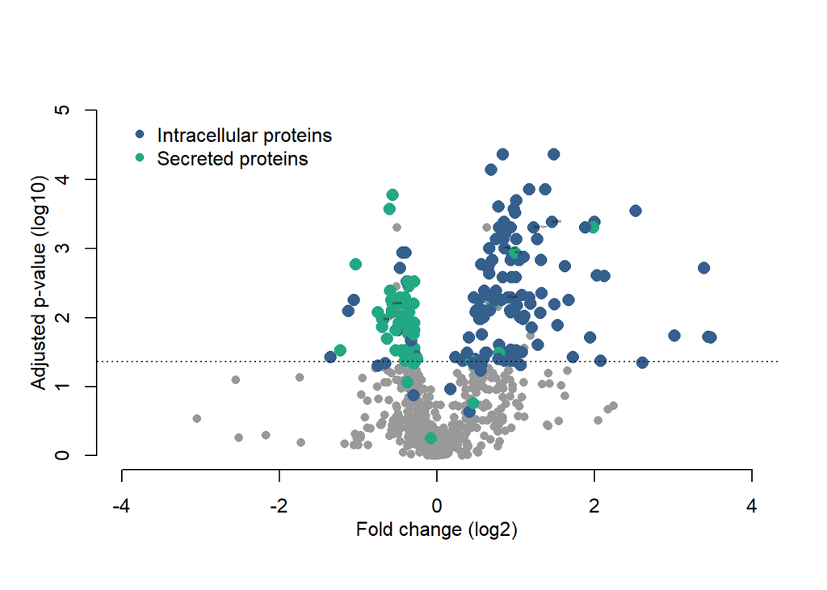

```r
# Set the plotting ranges.
xmin<--4
xmax<-4
ymin<-0.001
ymax<-5

# Create a PDF output of the Volcano Plot.
#pdf("volcanoplot_significant_proteins_secreted_intracellular_labelled.pdf", height=7, width=8)

# Create the initial base plot.
plot.new() # Create a new plotting window
plot(df_graph_ordered$Logfold, # X axis values
     -log(df_graph_ordered$p_adjust, base=10), # Y axis values, log(10) value of p_adjust
     col=df_graph_ordered$colour, # Colour as defined above
     pch=16, # Filled circles
     cex=df_graph_ordered$order, # Point size as defined above
     xlab="", # No x axis label
     ylab="", # No y axis label
     xlim=c(xmin,xmax), # Define x axis limits
     ylim=c(ymin,ymax), # Define y axis limits
     axes=F # Sepress plotting of axes
     )

# Add x and y axis.
axis(1)
axis(2)

# Add the specific protein labels.
text(df_graph_ordered$Logfold[df_graph_ordered$gene_symbol %in% labels],
     -log(df_graph_ordered$p_adjust, base=10)[df_graph_ordered$gene_symbol %in% labels],
     labels,
     adj=c(0,0),
     cex=0.2
     )

# Add a plot title and legend.
title(xlab="Fold change (log2)", ylab="Adjusted p-value (log10)",mgp=c(2,2,0))
legend(xmin,y=(1*ymax),  legend = c("Intracellular proteins", "Secreted proteins"),
       pch = 16, col = c("#355f8d","#22a884"), cex = 1, horiz=F,box.lwd = 0,box.col = "white",bg = "white")

# Add a horizontal dashed line to represent significance.
abline(h=1.36437635,lty=3)
```

```r
# Save the PDF file
#dev.off()
```

## Figure 2.

Code to generate the Raincloud plots. The anatomical diagram was generated in Illustrator.

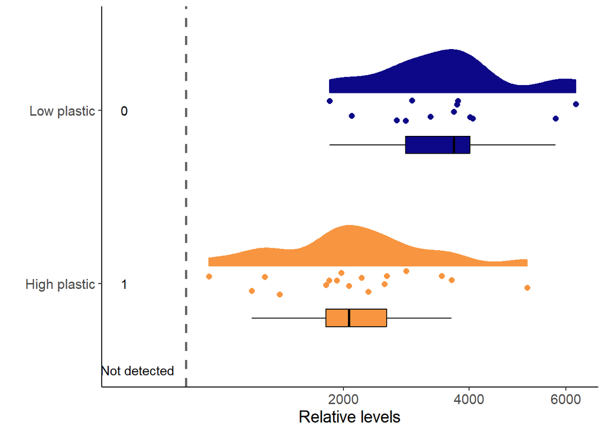

```r
# Figure 2 genes to graph include "BDNF", "PGA5", "ALB" and "GPX3".
gene_to_graph<-"BDNF" # Swap the gene symbol to the protein to be graphed using the gene symbol.

# Subset the data columns for the specified gene.
protein_Count<-df_graph[df_graph$gene_symbol==gene_to_graph, 5:35]

# Calculate the sum of the protein count and ignore the missing values.
protein_Count<-colSums(protein_Count, na.rm=F)

# Create a new dataframe with columns 'group_trimmed' and 'protein count'
graph_data<-data.frame(group_trimmed, as.numeric(protein_Count))

# Rename the columns
colnames(graph_data)<-c("Plastics", "Protein_count")

# Calculate the number of birds where the protein was not detected in each group.
missing<-c(sum(is.na(graph_data$Protein_count[graph_data$Plastics=="High Plastic"])),
           sum(is.na(graph_data$Protein_count[graph_data$Plastics=="Low Plastic"])))

# Generating a color palette named "colours" with two colourblind friendly colours
colours <- c("#f89540", "#0d0887")

# Creating a base ggplot
rain_cloud_plot <- ggplot(graph_data, aes(Plastics, Protein_count, fill = Plastics, col = Plastics)) +
  geom_flat_violin(position = position_nudge(x = 0.1, y = 0), alpha = 1, width = 0.5) + # Add a flat violin plot with some horizontal position       adjustment and transparency
  geom_point(position = position_jitterdodge(dodge.width = 0.15, jitter.width = 0.15), size = 2, alpha = 1) + # Add points to the plot with          jittering and dodging for better visualization, along with some transparency
  geom_boxplot(color = "black", width = 0.1, outlier.shape = NA, alpha = 1, position = position_nudge(x = -0.2, y = 0)) + # Add a black box plot,    no outliers, some transparency, and horizontal position adjustment
  coord_flip() + # Flip the x and y axes (transposing) to create a horizontal plot
  labs(x = "", y = "Relative levels") + # Set the x and y axis labels
  scale_y_continuous(trans = "sqrt") + # Adjust the y-axis scale to a square root transformation
  theme_classic() + # Apply classic theme
  theme(legend.position = "none") + # Remove the legend
  theme(text = element_text(size = 14)) + # Text elements font size
  scale_fill_manual(values = colours) + # Apply colour palette created above
  scale_colour_manual(values = colours)+ # Apply colour palette created above
  scale_x_discrete(labels=c("High plastic", "Low plastic")) + # Relabel x axis
  #Annotate the missing values
  annotate("text", label = missing, x = levels(as.factor(graph_data$Plastics)), y= c(min(graph_data$Protein_count, na.rm=T)/4))+
  annotate("text", label = "Not detected", x = 0.5, y = c(min(graph_data$Protein_count, na.rm=T)/3))+
  geom_hline(yintercept=min(graph_data$Protein_count, na.rm=T)*3/4, linetype = 'dashed', col = "#666666", size=1) # Creates a line separating the   detected and non-detected.

# Displaying the plot
rain_cloud_plot
```

```r
# Saving the plot file
ggsave("protein_XXX_raincloud.pdf", plot = rain_cloud_plot, width = 12, height = 6)
```

## Figure 3a.

Volcano plot of brain intracellular and secreted proteins

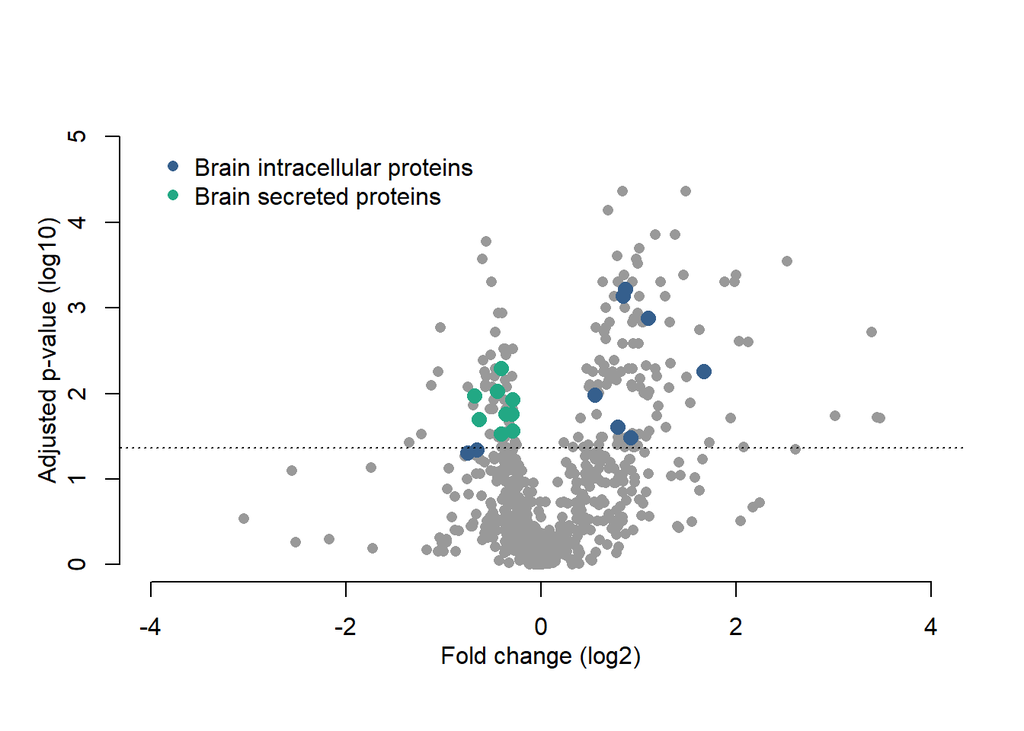

```r
# Create a list for specific proteins of interest
brain_secreted <- list("OLFM1", "BDNF", "APOD", "CNMD", "ENPP2", "PROS1", "SERPIND1", "SERPINF1", "SOD3")
brain_intracellular <- list("ACTR3B", "FKBP4", "OPCML", "OPCML", "PCBP3", "TAGLN3", "YWHAG", "GPX1", "GSTM3", "AGA")

# The following code is annotated in Chunk 19 for Figure 1b with changes to the pathways selected. Swap pathway1 and pathway2 to brain_secreted and brain_intracelluar as listed above. Additionally change pdf file name and legend titles.

df_graph$Sig<-df_graph$p_adjust<0.05
df_graph$Up<-(df_graph$Logfold>0)*df_graph$Sig
df_graph$Down<-(df_graph$Logfold<0)*df_graph$Sig

df_graph$colour<-rep("#999999",nrow(df_graph))
pathway1<-brain_intracellular
pathway2<-brain_secreted

df_graph$colour[df_graph$gene_symbol %in% pathway1]<-"#355f8d"
df_graph$colour[df_graph$gene_symbol %in% pathway2]<-"#22a884"
df_graph$order<-rep(0.95,nrow(df_graph))
df_graph$order[df_graph$gene_symbol %in% c(pathway1,pathway2)]<-1.4

df_graph_ordered<-df_graph[order(df_graph$order,decreasing = F),]

xmin<--4
xmax<-4
ymin<-0.001
ymax<-5

#pdf("volcanoplot_brain_proteins.pdf", height=7, width=5)

plot( df_graph_ordered$Logfold,
      -log(df_graph_ordered$p_adjust, base=10),
      col=df_graph_ordered$colour,
      pch=16,
      cex=df_graph_ordered$order,
      xlab="",
      ylab="",
      xlim=c(xmin,xmax),
      ylim=c(ymin,ymax),
      axes=F)

axis(1)
axis(2)

title(xlab="Fold change (log2)", ylab="Adjusted p-value (log10)",mgp=c(2,2,0))

legend(xmin,y=(1*ymax),  legend = c("Brain intracellular proteins", "Brain secreted proteins"),
       pch = 16, col = c("#355f8d","#22a884"), cex = 1, horiz=F,box.lwd = 0,box.col = "white",bg = "white")
abline(h=1.36437635,lty=3)
```

```r
#dev.off()
```

## Figure 3b.

Volano plot of liver intracellular and secreted proteins

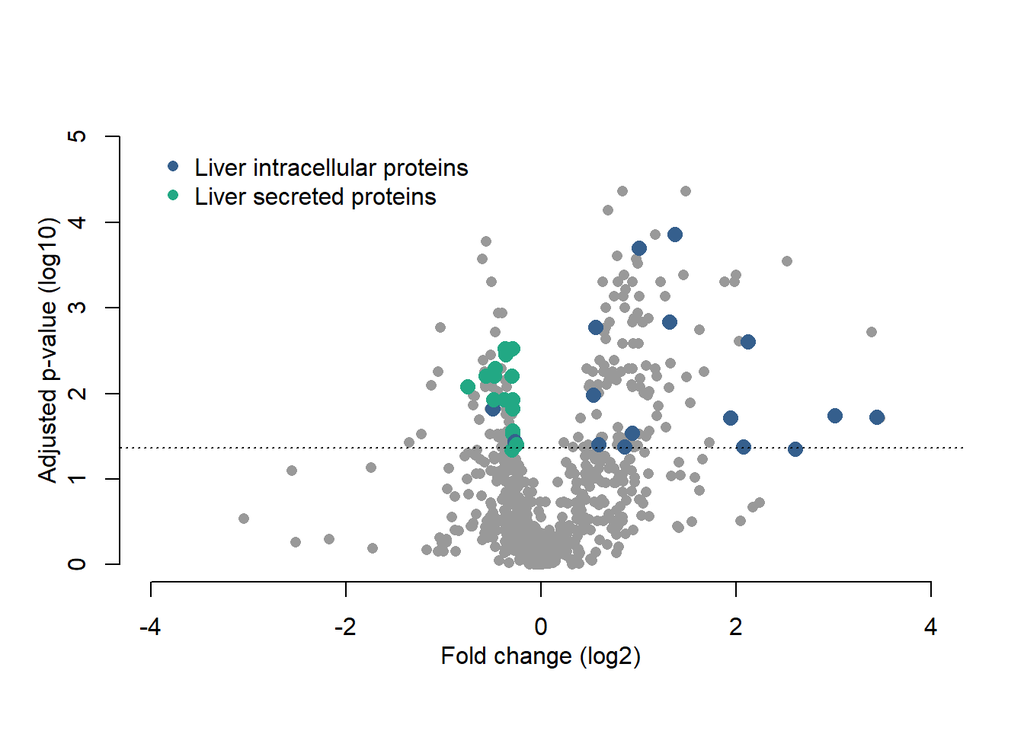

```r
# Create a list for specific proteins of interest
liver_secreted <- list("AGT", "ALB", "CFI", "F10", "F2", "F7", "GPLD1", "HABP2", "HGFAC", "IGFALS", "PROS1", "RBP4", "SELENOP", "SERPINC1", "SERPIND1", "SERPINF2")
liver_intracellular <- list("ADH5", "ADK", "ALDH9A1", "ALDOB", "BHMT", "CMPK1", "GSTM1", "HMGB3", "MAN1A1", "MINPP1", "PAICS", "PEBP1", "PRDX6", "PSMA3", "SAR1B", "SOD1")

# The following code is annotated in Chunk 19 for Figure 1b with changes to the pathways selected. Swap pathway1 and pathway2 to liver_secreted and liver_intracelluar as listed above. Additionally change pdf file name and legend titles.

df_graph$Sig<-df_graph$p_adjust<0.05
df_graph$Up<-(df_graph$Logfold>0)*df_graph$Sig
df_graph$Down<-(df_graph$Logfold<0)*df_graph$Sig

df_graph$colour<-rep("#999999",nrow(df_graph))
pathway1<-liver_intracellular
pathway2<-liver_secreted

df_graph$colour[df_graph$gene_symbol %in% pathway1]<-"#355f8d"
df_graph$colour[df_graph$gene_symbol %in% pathway2]<-"#22a884"
df_graph$order<-rep(0.95,nrow(df_graph))
df_graph$order[df_graph$gene_symbol %in% c(pathway1,pathway2)]<-1.4

df_graph_ordered<-df_graph[order(df_graph$order,decreasing = F),]

xmin<--4
xmax<-4
ymin<-0.001
ymax<-5

#pdf("volcanoplot_liver_proteins.pdf", height=7, width=5)

plot( df_graph_ordered$Logfold,
      -log(df_graph_ordered$p_adjust, base=10),
      col=df_graph_ordered$colour,
      pch=16,
      cex=df_graph_ordered$order,
      xlab="",
      ylab="",
      xlim=c(xmin,xmax),
      ylim=c(ymin,ymax),
      axes=F)

axis(1)
axis(2)

title(xlab="Fold change (log2)", ylab="Adjusted p-value (log10)",mgp=c(2,2,0))

legend(xmin,y=(1*ymax),  legend = c("Liver intracellular proteins", "Liver secreted proteins"),
       pch = 16, col = c("#355f8d","#22a884"), cex = 1, horiz=F,box.lwd = 0,box.col = "white",bg = "white")

abline(h=1.36437635,lty=3)
```

```r
#dev.off()
```

## Figure 3c.

Volcano plot of stomach secreted and kidney secreted proteins

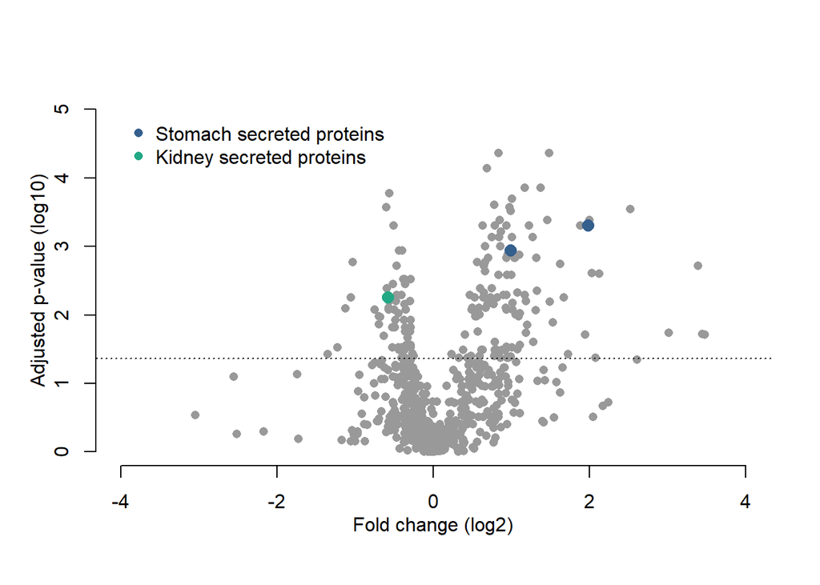

```r
# Create a list for specific proteins of interest
stomach_secreted <- list("GKN2", "PGA5")
kidney_secreted <- list("GPX3")

# The following code is annotated in Chunk 19 for Figure 1b with changes to the pathways selected. Swap pathway1 and pathway2 to stomach_secreted and kidney_secreted as listed above. Additionally change pdf file name and legend titles.

df_graph$Up<-(df_graph$Logfold>0)*df_graph$Sig
df_graph$Down<-(df_graph$Logfold<0)*df_graph$Sig

df_graph$colour<-rep("#999999",nrow(df_graph))
pathway1<-stomach_secreted
pathway2<-kidney_secreted

df_graph$colour[df_graph$gene_symbol %in% pathway1]<-"#355f8d"
df_graph$colour[df_graph$gene_symbol %in% pathway2]<-"#22a884"
df_graph$order<-rep(0.95,nrow(df_graph))
df_graph$order[df_graph$gene_symbol %in% c(pathway1,pathway2)]<-1.4

df_graph_ordered<-df_graph[order(df_graph$order,decreasing = F),]

xmin<--4
xmax<-4
ymin<-0.001
ymax<-5

#pdf("volcanoplot_stomach_kidney_proteins.pdf", height=7, width=5)

plot( df_graph_ordered$Logfold,
      -log(df_graph_ordered$p_adjust, base=10),
      col=df_graph_ordered$colour,
      pch=16,
      cex=df_graph_ordered$order,
      xlab="",
      ylab="",
      xlim=c(xmin,xmax),
      ylim=c(ymin,ymax),
      axes=F)

axis(1)
axis(2)

title(xlab="Fold change (log2)", ylab="Adjusted p-value (log10)",mgp=c(2,2,0))

legend(xmin,y=(1*ymax),  legend = c("Stomach secreted proteins", "Kidney secreted proteins"),
       pch = 16, col = c("#355f8d","#22a884"), cex = 1, horiz=F,box.lwd = 0,box.col = "white",bg = "white")

abline(h=1.36437635,lty=3)
```

```r
#dev.off()
```

## Figure 3d.

Heatmap of brain intracellular and secreted proteins

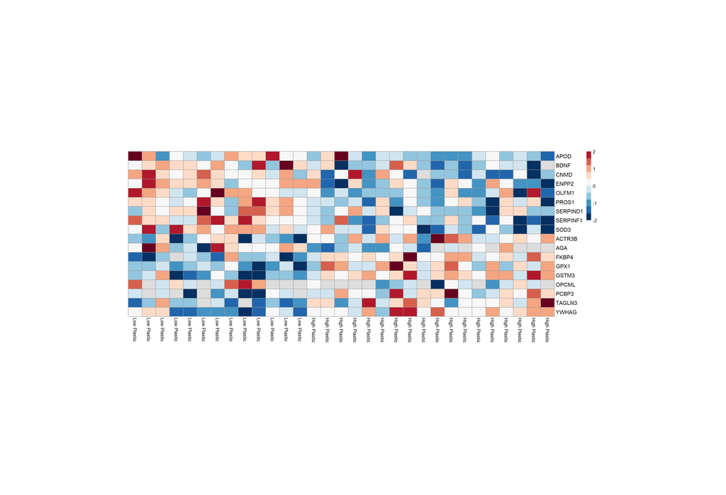

```r
# Combine the proteins from brain_secreted and brain_intracellular into one list
genes_for_pathway <- list("APOD", "BDNF", "CNMD", "ENPP2", "OLFM1", "PROS1", "SERPIND1", "SERPINF1", "SOD3","ACTR3B", "AGA", "FKBP4", "GPX1", "GSTM3", "OPCML", "OPCML", "PCBP3", "TAGLN3", "YWHAG")

# Creating the dataframe of the genes from df_graph
pre_heatmap_df<-df_graph[df_graph$gene_symbol %in%   genes_for_pathway  ,c(5:35,37)]

# Ordering proteins to be in alphabetical order displayed as secreted then intracellar
custom_order <- c("APOD", "BDNF", "CNMD", "ENPP2", "OLFM1", "PROS1", "SERPIND1", "SERPINF1", "SOD3","ACTR3B", "AGA", "FKBP4", "GPX1", "GSTM3", "OPCML", "OPCML", "PCBP3", "TAGLN3", "YWHAG")

# Reduce the pre_heatmap_df to only contain genes_for_pathway
pre_heatmap_df <- pre_heatmap_df[order(match(pre_heatmap_df$gene_symbol, custom_order)),]

# Z scoring
pre_heatmap_df[,1:length(group_trimmed)]<-sqrt(pre_heatmap_df[,1:length(group_trimmed)])
pre_heatmap_df$rowmean<-rowMeans(pre_heatmap_df[1:length(group_trimmed)], na.rm=T)
pre_heatmap_df$rowSD<-apply(pre_heatmap_df[1:length(group_trimmed)],1, sd, na.rm=T)

# Z scores into a new dataframe to replace raw protein counts
heatmap_df<-pre_heatmap_df[,1:length(group_trimmed)]

# Standardised scores
for(i in 1:nrow(pre_heatmap_df)){
    heatmap_df[i,]<-(pre_heatmap_df[i,1:length(group_trimmed)]-pre_heatmap_df$rowmean[i])/pre_heatmap_df$rowSD[i]

}

# Reordering the dataframe in order of quantity of plastic exposure from low plastic to high plastic
heatmap_df<-heatmap_df[, c("91084", "91058", "91074", "91055", "91085", "91053", "91081", "91082", "91064", "91051", "89704", "91057", "91073", "91091", "91094", "91076", "91089", "91087", "91062", "91095", "91099", "89701", "91097", "91059", "91054", "91098", "89703", "89702", "91075", "91096", "91093")]

pheatmap(heatmap_df,# Data frame containing the values above to create a heatmap using pheatmap
         labels_row=pre_heatmap_df$gene_symbol, # Label the rows of the heatmap with the gene symbol
         scale = "row",
         labels_col=group_trimmed[c(which(group_trimmed=="Low Plastic"), which(group_trimmed=="High Plastic"))], # Label the columns as Low or High plastic exposure
         fontsize_row=12, # Font size for row labels
         cluster_cols = F, cluster_rows = F, # Disables clustering of columns and rows
         legend=T, # Displays the legend for the colour spectrum
         cellwidth = 30, cellheight = 20,# Sets the dimensions of each cell within the heatmap
         breaks=seq(-2,2, length.out =11), # Defines the colour spectrum, how many colours out of 11 colours
         color = rev(brewer.pal(11, "RdBu"))) # Using the RdBu palette from the RColorBrewer package reversed so blue is negative and red is positive
```

## Figure 3e.

Heatmap of liver intracellular and secreted proteins

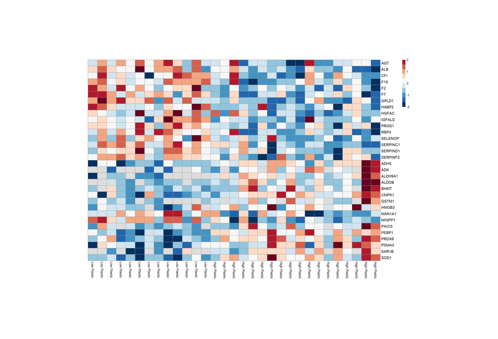

```r
# The following code is annotated in Chunk 24 for Figure 3d with changes to the genes for pathways.

# Combine the proteins from liver_secreted and liver_intracellular into one list
genes_for_pathway<- list("AGT", "ALB", "CFI", "F10", "F2", "F7", "GPLD1", "HABP2", "HGFAC", "IGFALS", "PROS1", "RBP4", "SELENOP", "SERPINC1", "SERPIND1", "SERPINF2", "ADH5", "ADK", "ALDH9A1", "ALDOB", "BHMT", "CMPK1", "GSTM1", "HMGB3", "MAN1A1", "MINPP1", "PAICS", "PEBP1", "PRDX6", "PSMA3", "SAR1B", "SOD1")

pre_heatmap_df<-df_graph[df_graph$gene_symbol%in%   genes_for_pathway  ,c(5:35,37)]

custom_order <- c("AGT", "ALB", "CFI", "F10", "F2", "F7", "GPLD1", "HABP2", "HGFAC", "IGFALS", "PROS1", "RBP4", "SELENOP", "SERPINC1", "SERPIND1", "SERPINF2", "ADH5", "ADK", "ALDH9A1", "ALDOB", "BHMT", "CMPK1", "GSTM1", "HMGB3", "MAN1A1", "MINPP1", "PAICS", "PEBP1", "PRDX6", "PSMA3", "SAR1B", "SOD1")

pre_heatmap_df <- pre_heatmap_df[order(match(pre_heatmap_df$gene_symbol, custom_order)),]

pre_heatmap_df[,1:length(group_trimmed)]<-sqrt(pre_heatmap_df[,1:length(group_trimmed)])
pre_heatmap_df$rowmean<-rowMeans(pre_heatmap_df[1:length(group_trimmed)], na.rm=T)
pre_heatmap_df$rowSD<-apply(pre_heatmap_df[1:length(group_trimmed)],1, sd, na.rm=T)

heatmap_df<-pre_heatmap_df[,1:length(group_trimmed)]

for(i in 1:nrow(pre_heatmap_df)){
    heatmap_df[i,]<-(pre_heatmap_df[i,1:length(group_trimmed)]-pre_heatmap_df$rowmean[i])/pre_heatmap_df$rowSD[i]

}

heatmap_df<-heatmap_df[, c("91084", "91058", "91074", "91055", "91085", "91053", "91081", "91082", "91064", "91051", "89704", "91057", "91073", "91091", "91094", "91076", "91089", "91087", "91062", "91095", "91099", "89701", "91097", "91059", "91054", "91098", "89703", "89702", "91075", "91096", "91093")]

pheatmap(heatmap_df,
         labels_row=pre_heatmap_df$gene_symbol,
         scale = "row",
         labels_col=group_trimmed[c(which(group_trimmed=="Low Plastic"), which(group_trimmed=="High Plastic"))],
         fontsize_row=12,
         cluster_cols = F, cluster_rows = F,
         legend=T,
         cellwidth = 30, cellheight = 20,
         breaks=seq(-2,2, length.out =11),
         color = rev(brewer.pal(11, "RdBu")))
```